# Lab 5

Ashley Sackpraseuth

11/7/2020

### Data Background: FARS Data

```r
library(tidyverse)
#FARS Data
acc <- read.csv("https://raw.githubusercontent.com/xdaiISU/ds202materials/master/hwlabs/fars2017/accident.csv", stringsAsFactors = FALSE)

pers <- read.csv("https://raw.githubusercontent.com/xdaiISU/ds202materials/master/hwlabs/fars2017/person.csv", stringsAsFactors = FALSE)

#Code --> Name Files
state_code <- read.csv("stateCodes.csv")
make_code <- read.csv("makeCodes.csv")
county_code <- readxl::read_xlsx("countyCodes.xlsx")
```

```r
#Map_data
states <- map_data("state")
counties <- map_data("county")
```

### Questions

1. Are there some days of the week where more accidents happen than the others (see FARS manual, use variable `DAY_WEEK`)?

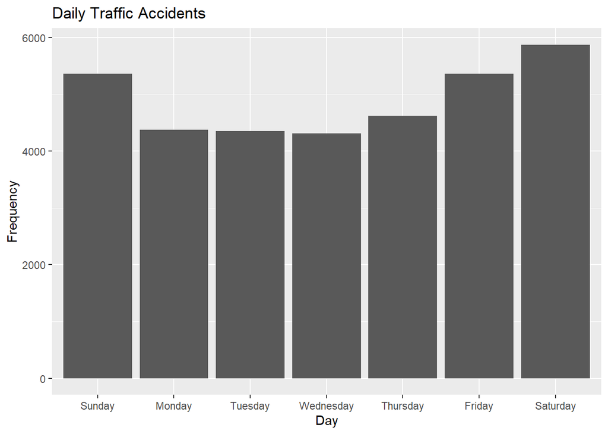

```r
acc %>%
  mutate(day_of_week = case_when(
    DAY_WEEK == 1 ~ "Sunday",
    DAY_WEEK == 2 ~ "Monday",
    DAY_WEEK == 3 ~ "Tuesday",
    DAY_WEEK == 4 ~ "Wednesday",
    DAY_WEEK == 5 ~ "Thursday",
    DAY_WEEK == 6 ~ "Friday",
    DAY_WEEK == 7 ~ "Saturday",
    DAY_WEEK == 9 ~ "Unknown",
    DAY_WEEK == "-" ~ "Unknown")) %>%
    mutate(day_of_week = factor(day_of_week, levels = c("Sunday", "Monday", "Tuesday", "Wednesday", "Thursday", "Friday", "Saturday", "Unknown"))) %>%
  ggplot(aes(x = day_of_week)) + geom_bar() + ggtitle("Daily Traffic Accidents") + xlab("Day") + ylab("Frequency")
```

Accidents happen more on the weekends (Friday-Sunday) than weekdays. Saturday has the highest number of car accidents. This is probaby because more people are out doing leisure activities during the weekend than during the weekdays.

2. Create a data frame containing the persons who are fatally hurt in the accidents (look up variable `INJ_SEV`)

```r
fatal <- pers %>%
  filter(INJ_SEV == 4)

head(fatal)
```

```
##   STATE ST_CASE VE_FORMS VEH_NO PER_NO STR_VEH COUNTY DAY MONTH HOUR MINUTE
## 1     1   10001        1      1      1       0     73  19     2   23     35
## 2     1   10002        1      1      1       0     89  14     2   14     59
## 3     1   10003        3      2      1       0    101  31     1   20     31
## 4     1   10004        1      1      1       0     73   1     1   16     55
## 5     1   10005        1      1      1       0     13   1     1   20      0
## 6     1   10006        2      1      1       0     49   6     1   18     40
##   RUR_URB FUNC_SYS HARM_EV MAN_COLL SCH_BUS MAKE MAK_MOD BODY_TYP MOD_YEAR
## 1       2        1      38        0       0   20   20421       15     2004
## 2       2        1       1        0       0   37   37402       14     2005
## 3       2        1      12        1       0    2    2404       14     2003
## 4       2        4      30        0       0   30   30046        4     2014
## 5       1        1      35        0       0   12   12471       34     2010
## 6       1        1      34        0       0   49   49032        4     1997
##   TOW_VEH SPEC_USE EMER_USE ROLLOVER IMPACT1 FIRE_EXP AGE SEX PER_TYP INJ_SEV
```

[output cut: 41 more lines]

3. Create a data frame containing the most dangerous vehicle make in each state. The number of persons fatally hit in the vehicle make is used to assess the (non-)safety of a make. Make sure to handle the missing values appropriately. (look up variable `MAKE`)

```r
fatal <- fatal %>%
  rename(StateCode = STATE, MakeCode= MAKE)

state_code <- rename(state_code, StateCode = Codes)
make_code <- rename(make_code, MakeCode = Codes)


dangerous_vehicles <- fatal %>%
  filter(!(MakeCode == "NA")) %>%
  left_join(state_code, by = "StateCode") %>%
  left_join(make_code, by = "MakeCode") %>%
  group_by(State, Make) %>%
  summarize(n = n()) %>%
  group_by(State) %>%
  filter(n == max(n))
dangerous_vehicles
```

```
## # A tibble: 54 x 3
## # Groups:   State [51]
##    State                Make          n
##    <fct>                <fct>     <int>
##  1 Alabama              Ford        138
##  2 Alaska               Ford          9
##  3 Arizona              Chevrolet    88
##  4 Arkansas             Chevrolet    88
##  5 California           Toyota      351
##  6 Colorado             Ford         63
##  7 Colorado             Honda        63
##  8 Connecticut          Honda        28
##  9 Delaware             Honda        12
## 10 District of Columbia Honda         5
## # ... with 44 more rows
```

4. Create a map, and label each state with the most dangerous vehicle. Discuss the definition of the most dangerous vehicle, and what you find from the map. (Hint: Read the description for the STATE and COUNTY columns in the FARS manual. The state & county codes are Geographic Locator Codes (GLCs) from the General Services Administration’s (GSA) publication. Use `readxl::read_xlsx` to read in the GLCs.)

```r
dangerous_vehicles$region <- tolower(dangerous_vehicles$State)

#State we don't have map data for
nomatch1 <- dangerous_vehicles %>% anti_join(states, by = "region")
unique(nomatch1)
```

```
## # A tibble: 2 x 4
## # Groups:   State [2]
##   State  Make       n region
##   <fct>  <fct>  <int> <chr>
## 1 Alaska Ford       9 alaska
## 2 Hawaii Toyota    21 hawaii
```

```r
#States we don't have fatal accidents data for
nomatch2 <- states %>% anti_join(dangerous_vehicles, by = "region")
unique(nomatch2)
```

```
## [1] long      lat       group     order     region    subregion
## <0 rows> (or 0-length row.names)
```

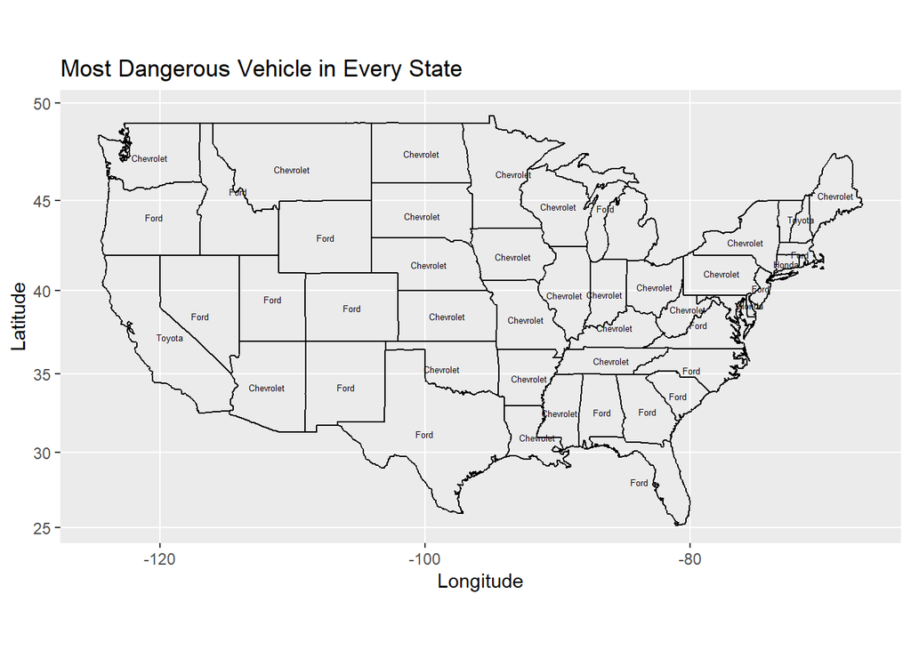

```r
#Creating label placement for map
make_name <- states %>%
  group_by(region) %>%
  summarize(long = ((min(long) + max(long))/2), lat = (((min(lat) + max(lat))/2))) %>%
  left_join(dangerous_vehicles, by = "region")
vehicle_map <- dangerous_vehicles %>%
  left_join(states, by = "region")

#Plot
ggplot(vehicle_map, aes(x = long, y = lat)) + geom_path(aes(group = group)) +
  geom_text(aes(label = Make), color = 'black', data=make_name, size = 1.7, check_overlap = TRUE) +
  coord_map() + ggtitle("Most Dangerous Vehicle in Every State") + xlab("Longitude") + ylab("Latitude")
```

(Note: This was the maximum font size I could have before the `check.overlap = TRUE` function removed certain state labels to make the map easier to read.) The most dangerous vehicle (per state) is defined as the Vehicle Make with the highest number of fatal accidents. Based on this map, Ford and Chevrolet are dangeous vehicles because these Makes have the highest number of fatal accidents in 46 states. Chevrolet, especially, appears to be the most dangerous vehicle in the midwest.

5. Join the accident and person table (work out which variable(s) to use)

```r
#Find variables accident and person tables have in common
intersect(colnames(acc), colnames(pers))
```

```
##  [1] "STATE"    "ST_CASE"  "VE_FORMS" "COUNTY"   "DAY"      "MONTH"
##  [7] "HOUR"     "MINUTE"   "RUR_URB"  "FUNC_SYS" "HARM_EV"  "MAN_COLL"
## [13] "SCH_BUS"
```

```r
#Join by those variables
acc_pers <- acc %>%
  full_join(pers, by = c("STATE", "ST_CASE", "VE_FORMS", "COUNTY", "DAY", "MONTH", "HOUR", "MINUTE", "RUR_URB", "FUNC_SYS", "HARM_EV", "MAN_COLL", "SCH_BUS"))

head(acc_pers)
```

```
##   STATE ST_CASE VE_TOTAL VE_FORMS PVH_INVL PEDS PERNOTMVIT PERMVIT PERSONS
## 1     1   10001        1        1        0    0          0       1       1
## 2     1   10002        1        1        0    0          0       1       1
## 3     1   10003        3        3        0    0          0       3       3
## 4     1   10003        3        3        0    0          0       3       3
## 5     1   10003        3        3        0    0          0       3       3
## 6     1   10004        1        1        0    0          0       1       1
##   COUNTY CITY DAY MONTH YEAR DAY_WEEK HOUR MINUTE NHS RUR_URB FUNC_SYS RD_OWNER
## 1     73  330  19     2 2017        1   23     35   1       2        1        1
## 2     89 1730  14     2 2017        3   14     59   1       2        1        1
## 3    101 2130  31     1 2017        3   20     31   1       2        1        1
## 4    101 2130  31     1 2017        3   20     31   1       2        1        1
## 5    101 2130  31     1 2017        3   20     31   1       2        1        1
## 6     73  350   1     1 2017        1   16     55   0       2        4        4
##   ROUTE        TWAY_ID       TWAY_ID2 MILEPT LATITUDE  LONGITUD SP_JUR HARM_EV
```

[output cut: 69 more lines]

6. Tally the number of accidents by day of the week (DAY_WEEK), hour of the day (HOUR) and gender (SEX). Visualize the results.

```r
#Recode
acc_pers <- acc_pers %>%
  mutate(day_of_week = case_when(
    DAY_WEEK == 1 ~ "Sunday",
    DAY_WEEK == 2 ~ "Monday",
    DAY_WEEK == 3 ~ "Tuesday",
    DAY_WEEK == 4 ~ "Wednesday",
    DAY_WEEK == 5 ~ "Thursday",
    DAY_WEEK == 6 ~ "Friday",
    DAY_WEEK == 7 ~ "Saturday",
    DAY_WEEK == 9 ~ "Unknown",
    DAY_WEEK == "-" ~ "Unknown")) %>%
  mutate(day_of_week = factor(day_of_week, levels = c("Sunday", "Monday", "Tuesday", "Wednesday", "Thursday", "Friday", "Saturday", "Unknown"))) %>%
  mutate(sex_recoded = case_when(
         SEX == 1 ~ "Male",
         SEX == 2 ~ "Female",
         SEX == 8 ~ "Not reported",
         SEX == "-" ~ "Not reported",
         SEX == 9 ~ "Unknown")) %>%
  mutate(sex_recoded = factor(sex_recoded, levels = c("Male", "Female", "Not reported", "Unknown")))


#Tally number of accidents
acc_pers %>%
  group_by(sex_recoded, day_of_week, HOUR) %>%
  summarise(n = n()) %>%
  group_by(sex_recoded) %>%
  filter(n == max(n)) %>%
  arrange(desc(n))
```

```
## # A tibble: 5 x 4
## # Groups:   sex_recoded [4]
##   sex_recoded  day_of_week  HOUR     n
##   <fct>        <fct>       <int> <int>
## 1 Male         Friday         18   596
## 2 Female       Friday         18   333
## 3 Unknown      Friday         21    22
## 4 Not reported Friday         21    15
## 5 Not reported Saturday       22    15
```

```r
dat <- acc_pers %>%
  group_by(sex_recoded, day_of_week, HOUR) %>%
  summarise(n = n())
```

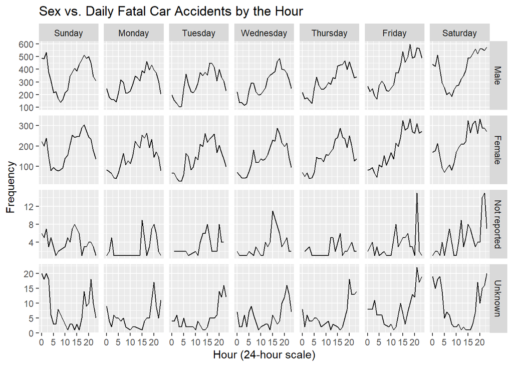

```r
#Visualize results
dat %>%
  filter(!(HOUR == 99))%>%
  ggplot(aes(x = HOUR, y = n)) + geom_line() + facet_grid(sex_recoded ~ day_of_week, scales = 'free') +
  ggtitle("Sex vs. Daily Fatal Car Accidents by the Hour") + xlab("Hour (24-hour scale)") + ylab("Frequency")
```

According to both the table and the graph, males driving at 6pm on a Friday night are the most likely to get in a fatal traffic accident. Friday nights have the highest number of fatal traffic accidents and early Tuesday mornings appear to have the least amount of fatal car accidents across the board, regardless of sex. Fatal traffic accident patterns are very similar for both males and females, but the y-axis for males is twice as much as the y-axis for females; males are more likely to get in a fatal traffic accident compared to anyone else.

7. Now plot a choropleth map of the number of deaths on a county level.

```r
#Reformatting county code to join with map_data(county)
county_code$`County Code` <- as.integer(county_code$`County Code`)


county_code$region <- tolower(county_code$`State Name`)
county_code$subregion <- tolower(county_code$`County Name`)

county_code <- county_code %>%
  rename(CountyCode = `County Code`) %>%
  select(CountyCode, region, subregion)


#Number of deaths here is defined as number of fatal traffic accents
fatal1 <- pers %>%
  filter(INJ_SEV == 4)

fatal1 <- fatal1 %>%
  rename(StateCode = STATE, CountyCode = COUNTY)




#Summarizing number of fatal traffic accdents by county
county_level <- fatal1 %>%
  left_join(state_code, by = "StateCode") %>%
  mutate(region = tolower(State)) %>%
  right_join(county_code, by = c("CountyCode", "region")) %>%
  group_by(region, subregion, CountyCode) %>%
  summarise(n = n()) %>%
  filter(n == max(n)) %>%
  rename(totDeaths = n)
#Counties we do not have map data for
nomatch3 <- county_level %>%
  anti_join(counties, by = c("region", "subregion"))
unique(nomatch3)
```

```
## # A tibble: 108 x 4
## # Groups:   region, subregion [108]
##    region  subregion            CountyCode totDeaths
##    <chr>   <chr>                     <int>     <int>
##  1 alabama dekalb                       49        22
##  2 alabama st. clair                   115        19
##  3 alaska  aleutians east               13         1
##  4 alaska  aleutians west               16         1
##  5 alaska  anchorage                    20        18
##  6 alaska  bethel                       50         4
##  7 alaska  bristol bay                  60         1
##  8 alaska  denali                       68         4
##  9 alaska  dillingham                   70         1
## 10 alaska  fairbanks north star         90        12
## # ... with 98 more rows
```

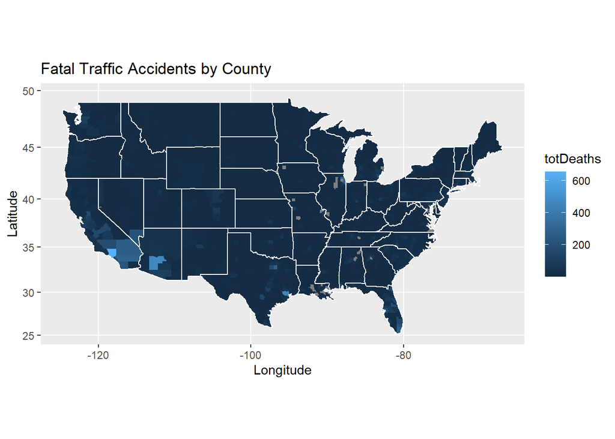

```r
#Plot
county_map <- county_level %>%
  right_join(counties, by = c("region", "subregion"))

ggplot(county_map, aes(x=long, y = lat, fill = totDeaths)) + geom_polygon(aes(group=group)) + coord_map() +  geom_path(data = states, aes(x = long, y = lat, group = group), inherit.aes=FALSE, size=0.5, color='white') +
  ggtitle("Fatal Traffic Accidents by County") + xlab("Longitude") + ylab("Latitude")
```

8. Is summer or winter more dangerous? Does this depend on states? Explore and explain.

```r
#Assuming summer: June, July, August
#Assuming winter: December, January, February

#Dangerous is defined as total number of fatal traffic accidents
fatal2 <- pers %>%
  filter(INJ_SEV == 4)

sum_wint_comp <- fatal2 %>%
  mutate(season = case_when(
          MONTH == 6 ~ "Summer",
          MONTH == 7 ~ "Summer",
          MONTH == 8 ~ "Summer",
          MONTH == 12 ~ "Winter",
          MONTH == 1 ~ "Winter",
          MONTH == 2 ~ "Winter")) %>%
  group_by(season) %>%
  filter(!(season == "NA")) %>%
  summarize(n = n()) %>%
  arrange(desc(n))
#Overall season analysis
sum_wint_comp
```

```
## # A tibble: 2 x 2
##   season     n
##   <chr>  <int>
## 1 Summer  9930
## 2 Winter  8401
```

```r
#Season analysis by state
sum_wint_comp2 <- fatal2 %>%
  mutate(season = case_when(
          MONTH == 6 ~ "Summer",
          MONTH == 7 ~ "Summer",
          MONTH == 8 ~ "Summer",
          MONTH == 12 ~ "Winter",
          MONTH == 1 ~ "Winter",
          MONTH == 2 ~ "Winter")) %>%
  rename(StateCode = STATE) %>%
  left_join(state_code, by = "StateCode") %>%
  group_by(season, State) %>%
  filter(!(season == "NA")) %>%
  summarize(n = n()) %>%
  group_by(State) %>%
  filter(n == max(n)) %>%
  arrange(desc(n)) %>%
  mutate(season_death = ifelse(season == "Winter", -1*n, n))
```

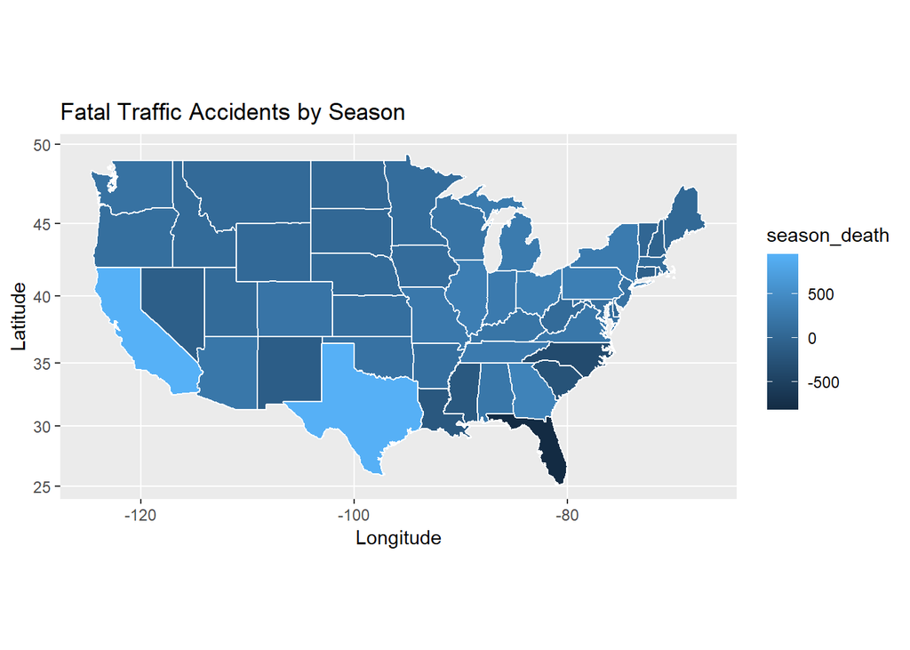

```r
sum_wint_comp2_map <- sum_wint_comp2 %>%
  mutate(region = tolower(State)) %>%
  right_join(states, by = "region")

#Plot
ggplot(sum_wint_comp2_map, aes(x=long, y = lat, fill = season_death)) + geom_polygon(aes(group=group)) + coord_map() + geom_path(data = states, aes(x = long, y = lat, group = group), inherit.aes=FALSE, size=0.5, color='white') +
  ggtitle("Fatal Traffic Accidents by Season") + xlab("Longitude") + ylab("Latitude")
```

The more dangerous season depends on the state, as seen by the chloropeth math. Dangerous was measured by the number of fatal accidents in a state. In order to acheive showing both the season and number of fatal accidents in one map, I multiplied the number of fatal accidents in states that had winter as their more dangerous season by -1. So although the negative scale on the right might not make the most sense at first (because a negative amount of deaths is not possible), visually, the map is still intuitive. The darker the state, the more fatal accidents occurred in the winter in that state. The lighter the state, the more fatal accidents occurred in the summer in that state. Majority of states had more fatal accidents in the summer than winter (which is confirmed by the table before the map). This may be because people have more leisure time to go out and make reckless decisions in the summer. I was surprised to see Florida have the most fatal accidents in the winter because I didn’t think the season-change affected Florida; I thought it was always hot all-year round. California and Texas have the highest number of fatal accidents occur in the summer but this may also be due to the fact that these states have a larger population compared to other states. Fatal accidents/per capita would give us a more accurate view of how the seasons affect the number of fatal traffic accidents.